**Analysis of the impact of average temperature and rainfall chages on the change in the average potato price in Peru in 2006-2015 years**

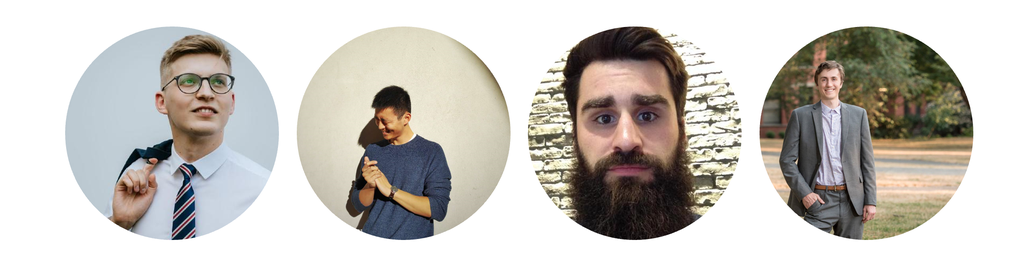

Produced by **Fabulous Group**:  
*Vitalii Zakhozhyi, Haotian Bu, Brady Nordstrom, Ian Langer*

**Contents:**

1. Introduction & Data Summary
2. Analysis
3. Research Findings & Conclusion

**Introduction & Data Summary**

**Introduction**

Peru is the main producer of potatoes in Latin America. The yield and price of potato are highly relevant with farmers’ income. It’s important for the government to share production trend information with farmers. To achieve this goal, the government need to identify some factors that influence the price of potato. This report explores the relationship between potato price and temperature and rainfall in Peru.

**Research Question**

The main research question is the following:

**Whether changes in average temperature and average level of rainfall affect the change in the average price on potatoes in Peru in 2006-2015 years?**

**Data**

Our dependent variable is the retail price of potato in Peru in 2006-2015 (in Peruvian Sol per 5kg).

The independent (explanatory) variables we used for the research incluse: *Near surface monthly mean air temperature (in °C).* Monthly precipitation sums (in mm) in Peru in 2006-2015. Except missing data in Mar 2013.

Go back to the table of contents

**Analysis**

**Importing final dataset**

In this section we imported the cleaned dataset:

```r
link = "https://raw.githubusercontent.com/vzakhozhyi/599-A-Final-Project/master/Data%20Final/DataFinal.csv"
df=read.csv(link,stringsAsFactors = FALSE)
```

Check the content:

```r
str(df)
```

```
## 'data.frame':    119 obs. of  8 variables:
##  $ country    : chr  "Peru" "Peru" "Peru" "Peru" ...
##  $ crop       : chr  "Potatoes" "Potatoes" "Potatoes" "Potatoes" ...
##  $ year       : int  2006 2006 2006 2006 2006 2006 2006 2006 2006 2006 ...
##  $ month      : int  1 2 3 4 5 6 7 8 9 10 ...
##  $ price      : num  1.05 1.17 1.21 1.21 1.12 1.05 1.02 1.02 1.08 1.08 ...
##  $ temperature: num  20.2 20 20.5 19.7 18.9 ...
##  $ rainfall   : num  233 198 209 160 134 ...
##  $ date       : Date, format: "2006-01-01" "2006-02-01" ...
```

Distribution of retail price of potato from 2006-2015:

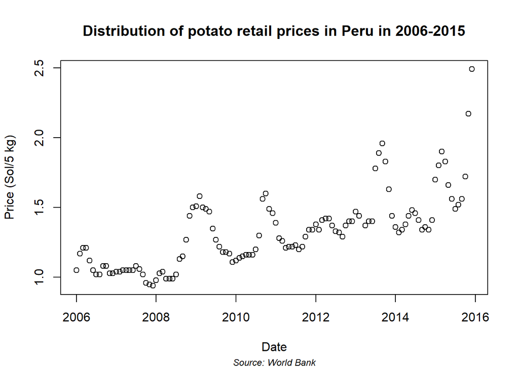

Distribution of temerature in Peru from 2006-2015:

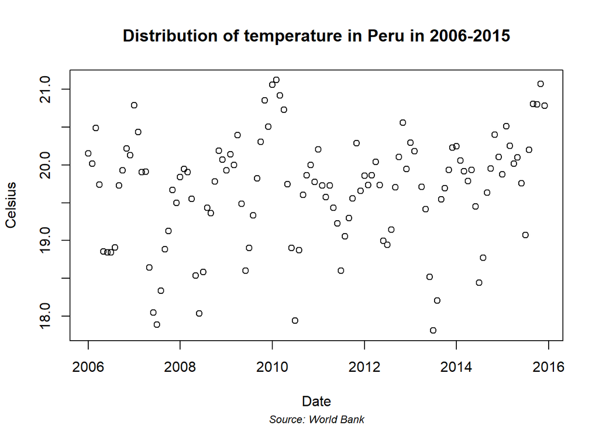

Distribution of rainfall from 2006-2015:

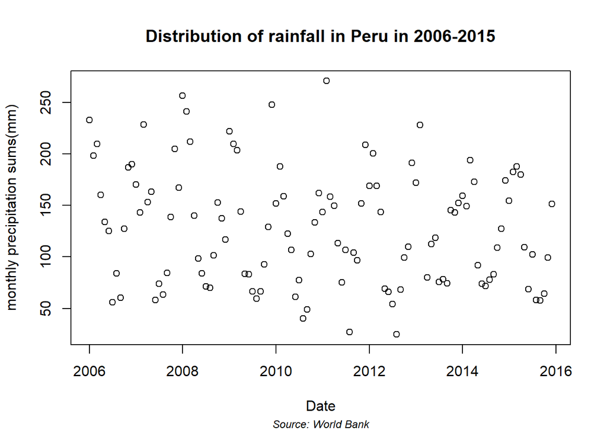

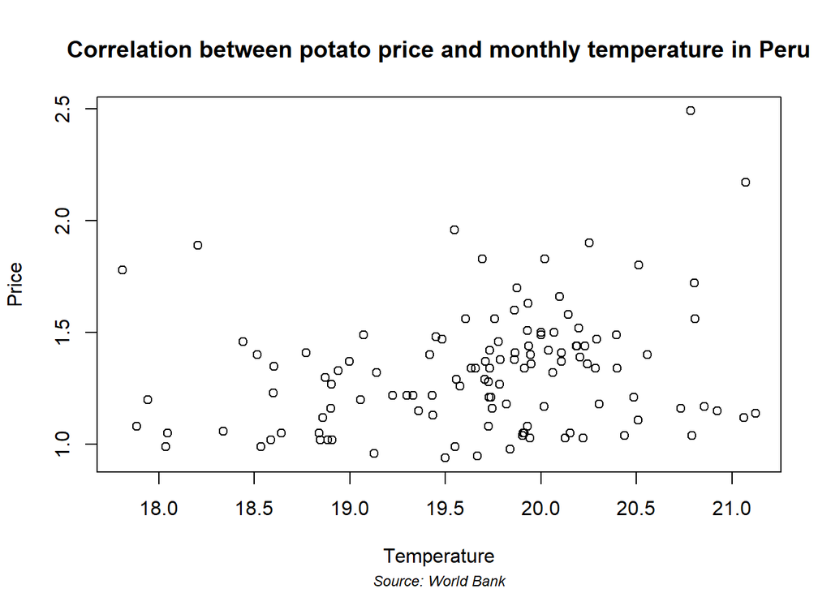

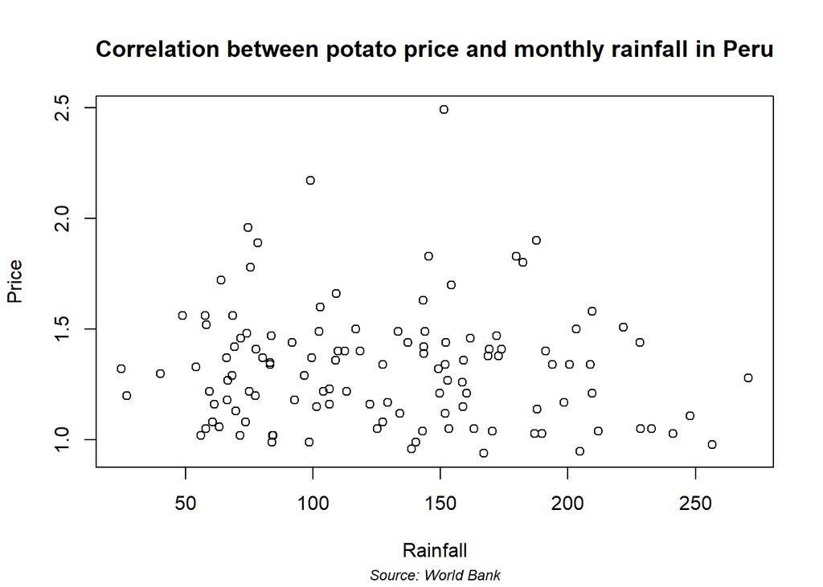

**Regression**

We suppose retail price of patato have a linear relationship with rainfall and temperature. Here we use **Linear Regression Model** to test our hypothesis:

```r
test=lm(price~rainfall+temperature,data=df)
summary(test)
```

```
##
## Call:
## lm(formula = price ~ rainfall + temperature, data = df)
##
## Residuals:
##      Min       1Q   Median       3Q      Max
## -0.37929 -0.18601 -0.02849  0.11291  1.04940
##
## Coefficients:
##               Estimate Std. Error t value Pr(>|t|)
## (Intercept) -1.0390498  0.6893982  -1.507 0.134482
## rainfall    -0.0011606  0.0004757  -2.440 0.016206 *
## temperature  0.1277528  0.0363739   3.512 0.000634 ***
## ---
## Signif. codes:  0 '***' 0.001 '**' 0.01 '*' 0.05 '.' 0.1 ' ' 1
##
## Residual standard error: 0.2545 on 116 degrees of freedom
## Multiple R-squared:  0.1017, Adjusted R-squared:  0.08618
## F-statistic: 6.564 on 2 and 116 DF,  p-value: 0.001992
```

Following chart shows coefficients of two explanatory variables.

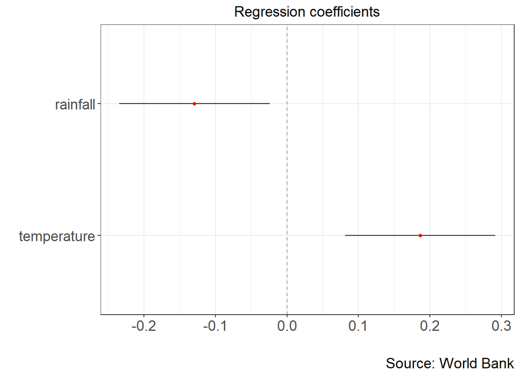

**Check assumptions of Linear Regression**

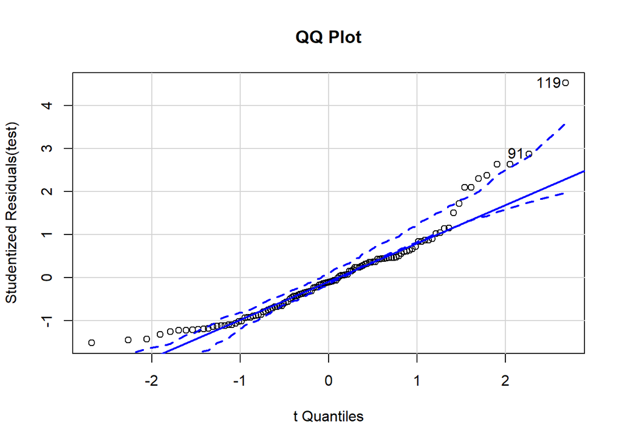

```
## [1]  91 119
```

```
## Non-constant Variance Score Test
## Variance formula: ~ fitted.values
## Chisquare = 2.523271, Df = 1, p = 0.11218
```

2. Explanatory variabels are not highly correlated:

```r
# collinearity?
vif(test) > 4 # problem?
```

```
##    rainfall temperature
##       FALSE       FALSE
```

3. Detect the change if influential observations are eliminated:

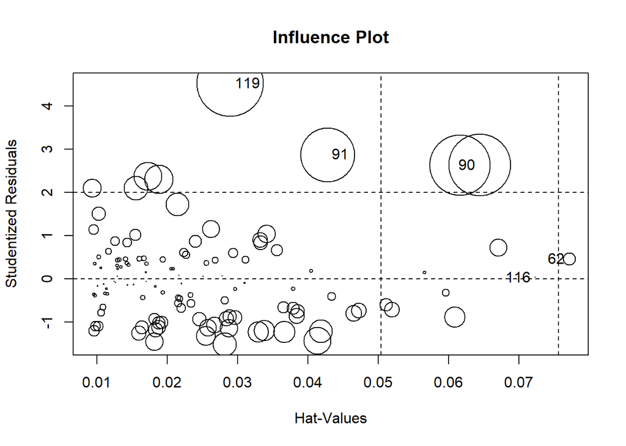

```
##        StudRes        Hat        CookD
## 62  0.46085088 0.07717901 5.961288e-03
## 90  2.63012399 0.06446670 1.511817e-01
## 91  2.87362603 0.04276336 1.157272e-01
## 116 0.03138585 0.07235306 2.583314e-05
## 119 4.52189971 0.02896799 1.741375e-01
```

Those cases (rows) are not considered now:

```r
CountrysOUT=c(62,90,91,116,119)
newtest = lm(price~temperature+rainfall,
           data=df[-CountrysOUT,])
summary(newtest)
```

```
##
## Call:
## lm(formula = price ~ temperature + rainfall, data = df[-CountrysOUT,
##     ])
##
## Residuals:
##      Min       1Q   Median       3Q      Max
## -0.37854 -0.17615 -0.01781  0.12746  0.62373
##
## Coefficients:
##               Estimate Std. Error t value Pr(>|t|)
## (Intercept) -1.4657554  0.6535984  -2.243  0.02691 *
## temperature  0.1486177  0.0345264   4.304 3.62e-05 ***
## rainfall    -0.0012066  0.0004402  -2.741  0.00714 **
## ---
## Signif. codes:  0 '***' 0.001 '**' 0.01 '*' 0.05 '.' 0.1 ' ' 1
##
## Residual standard error: 0.2214 on 111 degrees of freedom
## Multiple R-squared:  0.1461, Adjusted R-squared:  0.1308
## F-statistic:   9.5 on 2 and 111 DF,  p-value: 0.0001555
```

Compare new regression result with before:

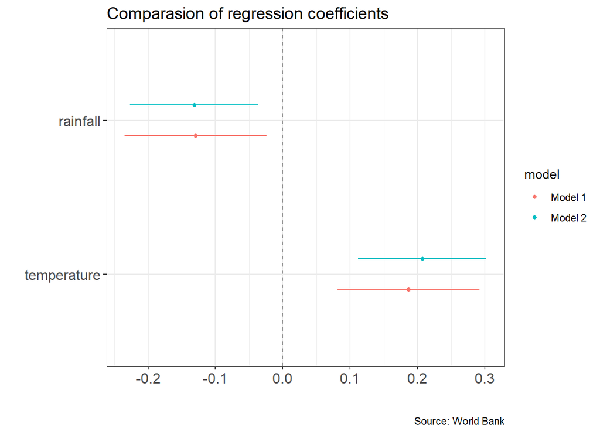

This plot shows predicted price and actual price:

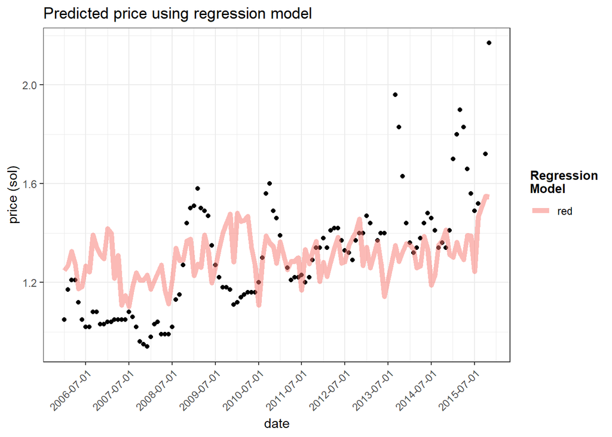

Go back to the table of contents

**Research Findings & Conclusion**

The regression analysis supported our hypoethesis: other things equal, rainfall and temperature have siginificant impacts on potato retail price. On average, 1 mm increase in monthly precipitation sums is correlated with 0.00116 Sol decrease in potato price, 1 degree Celsius increase in monthly mean air temprature is correlated with 0.128 Sol increase in potato price.

Go back to top of the page

Go back to the table of contents

[Go to the Project Repo](https://github.com/vzakhozhyi/599-A-Final-Project) ___________